# Document Classification

Pavan Akula

April 10, 2017

## Abstract

The goal of this project is to classify documents (unstructured data) using various supervised and unsupervised machine learning techniques. The documents used in this project are harvested from [*The American Presidency Project (APP)*](http://www.presidency.ucsb.edu), non-profit and non-partisan website, hosted at the University of California, Santa Barbara. To demonstrate *natural language processing and machine learning* following techniques are used.

Supervised learning techniques

- KNN, K-Nearest Neighbour model
- SVM, Support Vector Machines model
- Random Forest Classifier
- Maximum Entropy Classifier

Unsupervised learning techniques

- LDA, Latent Dirichlet Allocation
- CTM, Correlated Topic Model

Libraries used.

```r
if (!require('rvest')) install.packages('rvest')                #Web scraping and text extraction
if (!require('plyr')) install.packages('plyr')                  #Data frame and table functions
if (!require('dplyr')) install.packages('dplyr')                #Data frame and table functions
if (!require('stringr')) install.packages('stringr')            #String manuplilation functions
if (!require('tm')) install.packages('tm')                      #Text cleaning and organization - Document-Term-Matrix
if (!require('class')) install.packages('class')                #KNN supervised learning
if (!require('RTextTools')) install.packages('RTextTools')      #For supervised learning SVM, MAXEXT
if (!require('randomForest')) install.packages('randomForest')  #Random Forest supervised learning
if (!require('caret')) install.packages('caret')                #For confusion matrix
if (!require('topicmodels')) install.packages('topicmodels')    #For unsupervised learning techniques LDA and CTM
if (!require('Rmpfr')) install.packages('Rmpfr')                #For calculating harmonic means
if (!require('ggplot2')) install.packages('ggplot2')            #Graphs package
if (!require('knitr')) install.packages('knitr')
#knitr::opts_chunk$set(error = TRUE)
```

## Data Source

Data used throughout the project is harvested from [*The American Presidency Project (APP)*](http://www.presidency.ucsb.edu/2016_election.php). We will be using campaign speeches and remarks made by President Donald Trump and Former Secretary of State Hillary Clinton during 2016 presidential campaign. More information about data can be found at http://www.presidency.ucsb.edu/2016_election.php. Following code connects to website and extracts data. Each speech is stored as a file.

```r
#Get links to all speeches
speeches <- function(urlHtml){
  #Ectract all tables
  speeches.getnodes <-  urlHtml %>% html_nodes(xpath = "//tr/td//table")

  #There are many tables on the page, table with attribute width="700" contains links to all speeches
  speeches.table.attrs <-  html_attr(speeches.getnodes,"width")
  #Get particular table with width="700"
  speeches.allUrls.table <- speeches.getnodes[match("700",speeches.table.attrs)]

  #Convert data into dataframe from HTML table
  speeches.df <- html_table(speeches.allUrls.table, fill=TRUE, header = TRUE)[[1]]
  speeches.df$fn <- gsub(pattern = "\\s+", replacement = "\\-", paste(speeches.df$Actor,speeches.df$Date,sep = "-"))
  speeches.df$fn <- gsub(pattern = "\\.", replacement = "", speeches.df$fn)
  speeches.df$fn <- gsub(pattern = "\\,", replacement = "", speeches.df$fn)

  #Get Links
  speechurl = speeches.allUrls.table %>%  html_nodes(xpath = "//a") %>% html_attr("href")
  speechurl <- gsub(pattern = "\\.\\.", replacement = "http://www.presidency.ucsb.edu", speechurl)
  speeches.df$speechurl <- cbind(unlist(speechurl[str_detect(speechurl, "pid")]))
  return(speeches.df)
}

#TryCatch block for handeling page encoding errors
read.speech.html <- function(weburl, encoding){
  speech.out <- tryCatch(read_html(weburl, encoding = encoding), error = function(e){"Error"})
  return(speech.out)
}

#Get text from each link and save as text file
speechdata <- function(df, folder){

  #Meta file with file names
  meta.speeches.file <- paste0(folder,"meta-speeches-file.csv")
  meta.speech.text <- paste("Candidate", "Date", "Title", "SpeechUrl", "FileName", sep = '","')
  meta.speech.text <- paste0('"', meta.speech.text, '"')
  write(meta.speech.text, file = meta.speeches.file, append = FALSE)

  #Loop through each link
  for(i in 1:nrow(df)){
    speechurl <- df[i,]$speechurl

    #Get data from webpage
    speech.html <- read.speech.html(speechurl, encoding = "")

    if (length(speech.html) < 2){
      speech.html <- read.speech.html(speechurl, encoding = "UTF-8")
    }

    if (length(speech.html) > 1){
      #Get nodes with have "span" tag
      speech.nodes <- html_nodes(speech.html, "span")

      #Get attributes of each node
      speech.attrs <- unlist(html_attrs(speech.nodes))

      #Get text for each node
      speech.nodes.text <- html_text(speech.nodes)

      #Node that has attribute class="displaytext" has actual text
      speech.text <- speech.nodes.text[match("displaytext", speech.attrs)]

      #Convert Unicode "UTF-8" to "ASCII"
      speech.text = iconv(speech.text, "UTF8", "ASCII", sub=" ")

      #Save text to folder
      speechFileName <- paste0(df[i,]$fn, "-", i, ".txt")
      fileFullPath <- paste0(folder, speechFileName)

      write(speech.text, file = fileFullPath, append = FALSE)

      meta.speech.text <- paste(df[i,]$Actor, df[i,]$Date, df[i,]$Title, df[i,]$speechurl, speechFileName, sep = '","')
      meta.speech.text <- paste0('"', meta.speech.text, '"')
      write(meta.speech.text, file = meta.speeches.file, append = TRUE)
    }

    Sys.sleep(2)
  }
}

#Create folder
folderDetails <- function(rootDir, subDir){
  dir.create(file.path(rootDir, subDir), showWarnings = FALSE)
  return(paste0(rootDir, subDir, "/"))
}

#Connect to website and download data
webDataDownload <- function(wUrl, saveDataFolder){
  webPageHtml <- read_html(wUrl)
  speeches.table <- speeches(webPageHtml)
  speechdata(speeches.table, saveDataFolder)
}

#Create folder to download files
wd <- getwd()
rootDir <- "D:/CUNY/607/Week10/Project04/" #Change path
candidateDirs <- c("DonaldTrump", "HillaryClinton", "DT_Nov", "HC_Nov")
fileDirs <- lapply(candidateDirs, folderDetails, rootDir = rootDir)
fileDirs <- as.character(unlist(fileDirs))

candidateUrls <- c("http://www.presidency.ucsb.edu/2016_election_speeches.php?candidate=45&campaign=2016TRUMP&doctype=5000", "http://www.presidency.ucsb.edu/2016_election_speeches.php?candidate=70&campaign=2016CLINTON&doctype=5000")

#Download data
for(i in 1:length(candidateUrls)){
  #Download data
  webDataDownload(candidateUrls[i], fileDirs[i])

  #Create Sample data, this data will be used for unsupervised learning techniques
   sample.files <- list.files(path = fileDirs[i], pattern = glob2rx("*November*2016*"), all.files = FALSE, full.names = TRUE, recursive = FALSE)
  file.copy(sample.files, fileDirs[i+2])
}
```

### Corpus and Document Term Matrix(DTM) generation

Once data extraction is complete, speeches document corpus is generated using `Corpus` function from `tm` package. Corpus is further cleaned for words `[applpause]`,`break`,`next` and `thank` and English language stop words (the, and, etc.). These words do not add value to the content of the speech. Using `stemDocument` function words such as `dependencies` and `dependent` is converted into stem word `depend`. `tm` package offers functions `DocumentTermMatrix` and `TermDocumentMatrix` to generate document and term matrix. `DocumentTermMatrix` function converts the `Corpus` into `Documents` as rows and `Words` as columns. Each `Word` inside the `Document` is known as `Term`. Whereas `TermDocumentMatrix` converts `Documents` as columns and `Terms` as rows. For the purpose of the project, we will be using `DocumentTermMatrix` function.

```r
#Read files, generate clean Corpus and Term Document Matrix
filesToDTM <- function(rootDir, subDir, pattern){
  #rootDir = "D:/CUNY/607/Week10/Project04/"
  #subDir = "DonaldTrump"
  #pattern = "txt$"
  # Get file list
  fileFolder <-paste0(rootDir, subDir, "/")
  fileList <- list.files(path = fileFolder, pattern = pattern, all.files = FALSE, full.names = TRUE, recursive = FALSE)

  #Generate corpus for filelist
  speech.corpus <- Corpus(URISource(fileList), readerControl = list(reader = readPlain, language = "en_US", load = TRUE))

  #Clean up the corpus
  speech.corpus <- tm_map(speech.corpus, removeWords, c("[applpause]","break","next", "thank"))
  speech.corpus <- tm_map(speech.corpus, removePunctuation)
  speech.corpus <- tm_map(speech.corpus, removeNumbers)
  speech.corpus <- tm_map(speech.corpus, stripWhitespace)
  speech.corpus <- tm_map(speech.corpus, content_transformer(tolower))
  speech.corpus <- tm_map(speech.corpus, PlainTextDocument)
  speech.corpus <- tm_map(speech.corpus, stemDocument)
  speech.corpus <- tm_map(speech.corpus, removeWords, stopwords("english"))

  #Generate Document Term Matrix
  speech.dtm <- DocumentTermMatrix(speech.corpus)
  speech.dtm <- removeSparseTerms(speech.dtm, 0.7)
  dtmOutput <- list(candidateSpeech = subDir, dtm = speech.dtm, speechFile = fileList)
  return(dtmOutput)
}

#Attach candidate names to DTM
attachCandidateToDTM <- function(speechDTM){
  speech.matrix <- data.matrix(speechDTM[["dtm"]])
  #Convert matrix to dataframe
  speech.df <- as.data.frame(speech.matrix, stringsAsFactors = F)

  #Apply candidate name to each row inside the frame
  speech.df <- cbind(speech.df, rep(speechDTM[["candidateSpeech"]], nrow(speech.df)))

  #Rename column
  colnames(speech.df)[ncol(speech.df)] <- "candidateSpeech"

  #Apply speech file name to each row inside the frame
  speech.df <- cbind(speech.df, speechDTM[["speechFile"]])

  #Rename column
  colnames(speech.df)[ncol(speech.df)] <- "speechFile"

  return(speech.df)
}

# Files to be used
files.pattern = "txt$"

#Convert files to Document Term Matrix
wd <- getwd()
rootDir <- "D:/CUNY/607/Week10/Project04/" #Change path
candidateDirs <- c("DonaldTrump", "HillaryClinton")
speechs.dtm <- lapply(candidateDirs, filesToDTM, rootDir = rootDir, pattern = files.pattern)

#Apply candidate name to speech
candidate.data <- lapply(speechs.dtm, attachCandidateToDTM)

#Get data for supervised learning
speech.data <- do.call(rbind.fill, candidate.data)
speech.data$candidateSpeech = ifelse(speech.data$candidateSpeech == "DonaldTrump", "Donald Trump", "Hillary Clinton")

#Replace missing values with 0
speech.data[is.na(speech.data)] <- 0

#Seperate data and candidate names
speech.data.candidates <- speech.data[,"candidateSpeech"]
speech.data.fileNames <- speech.data[,"speechFile"]

#Remove candidate and speech file info from Data frame speech.data.nocandidate, this data will be used for all supervised learning techniques
speech.data.nocandidate <- speech.data
speech.data.nocandidate$candidateSpeech <- NULL
speech.data.nocandidate$speechFile <- NULL

#Get data for unsupervised learning techniques. As unsupervised learning techniques are resourse and time consuming, data is limited to speeches given by both candidates in the month November, 2016.
nov.candidateDirs <- c("DT_Nov", "HC_Nov")
nov.speechs.dtm <- lapply(nov.candidateDirs, filesToDTM, rootDir = rootDir, pattern = files.pattern)

#Apply candidate name to speech
nov.candidate.data <- lapply(nov.speechs.dtm, attachCandidateToDTM)

nov.speech.data <- do.call(rbind.fill, nov.candidate.data)
nov.speech.data$candidateSpeech = ifelse(nov.speech.data$candidateSpeech == "DT_Nov", "Donald Trump", "Hillary Clinton")

#Replace missing values with 0
nov.speech.data[is.na(nov.speech.data)] <- 0

#Seperate data and candidate names
nov.speech.data.candidates <- nov.speech.data[,"candidateSpeech"]
nov.speech.data.fileNames <- nov.speech.data[,"speechFile"]

#Remove candidate and speech file info from Data frame nov.speech.data.nocandidate, this data will be used for all unsupervised learning techniques
nov.speech.data.nocandidate <- nov.speech.data
nov.speech.data.nocandidate$candidateSpeech <- NULL
nov.speech.data.nocandidate$speechFile <- NULL
```

### Generate Train and Test datasets

```r
#Create datasets, 70% - Training dataset, 30% - Testing dataset
set.seed(1974)
speech.train.test <- sample(2, nrow(speech.data.nocandidate), replace = TRUE, prob = c(0.7, 0.3))

train.data <- speech.data.nocandidate[speech.train.test == 1,]
test.data <- speech.data.nocandidate[speech.train.test == 2,]
```

## Supervised learning techniques

### k-Nearest Neighbour(kNN) model

In k-NN classification, the output is a class membership. An object is classified by a majority vote of its neighbors, with the object being assigned to the class most common among its k nearest neighbors (k is a positive integer, typically small). `knn` function is part of `class` package. `confusionMatrix` function is part of `caret` package.

The output of the kNN classification model suggests three documents are misclassified. Documents are classified as `Hillary Clinton` when the actual speech was delivered by President `Donald Trump`. The accuracy of the model is 96.05%. `class` package is used to demonstrate kNN model.

```r
#knn function takes parameters training dataset, test dataset and categorical attributes of training dataset, k-number of neighbors considered. Number of neighbors in our case is 10.
#In our case categorical attributes are candidate names.
train.candidates <- factor(speech.data.candidates[speech.train.test == 1])
knn.prediction <- class::knn(train = train.data, test = test.data, cl = train.candidates, k=10)

cm <- confusionMatrix(knn.prediction, speech.data.candidates[speech.train.test == 2])
#Save confusion Matrix output to data frame
cm.data <- as.data.frame(t(cm$byClass))
cm.data$Model <- "KNN"
cm
```

```
## Confusion Matrix and Statistics
##
##                  Reference
## Prediction        Donald Trump Hillary Clinton
##   Donald Trump              18               0
##   Hillary Clinton            3              55
##
##                Accuracy : 0.9605
##                  95% CI : (0.8889, 0.9918)
##     No Information Rate : 0.7237
##     P-Value [Acc > NIR] : 9.227e-08
##
##                   Kappa : 0.8967
##  Mcnemar's Test P-Value : 0.2482
##
##             Sensitivity : 0.8571
##             Specificity : 1.0000
##          Pos Pred Value : 1.0000
##          Neg Pred Value : 0.9483
##              Prevalence : 0.2763
##          Detection Rate : 0.2368
##    Detection Prevalence : 0.2368
##       Balanced Accuracy : 0.9286
##
##        'Positive' Class : Donald Trump
##
```

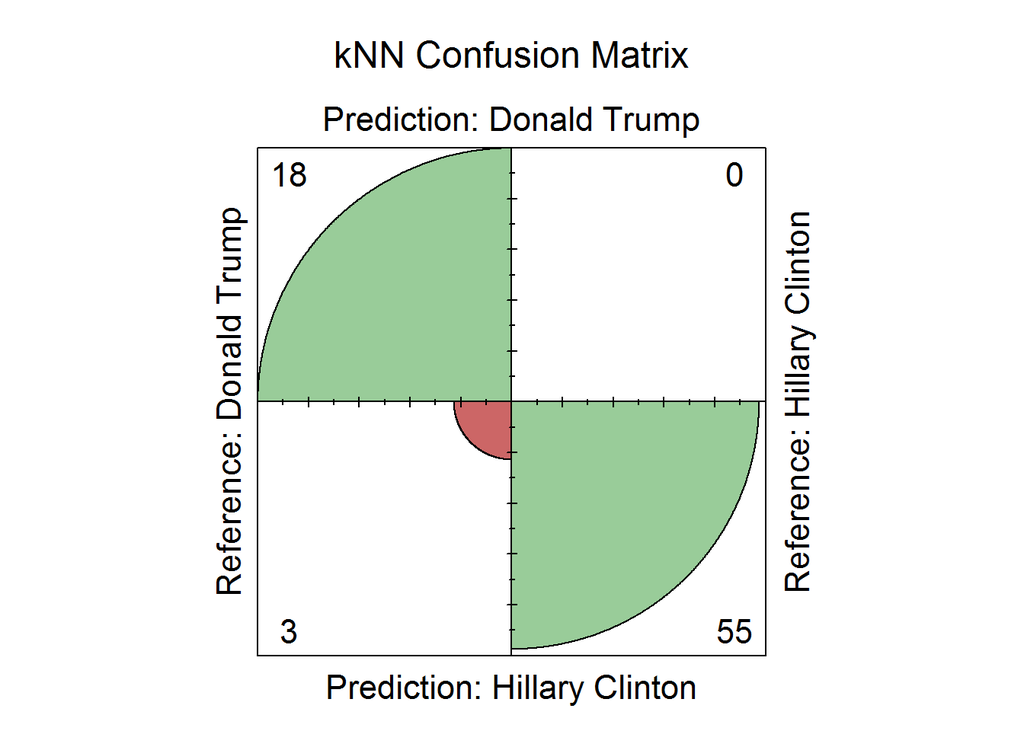

```r
fourfoldplot(cm$table, color = c("#CC6666", "#99CC99"),conf.level = 0, margin = 1, main = "kNN Confusion Matrix")
```

### Support Vector Machines(SVM) model

The output of the SVM classification model suggests two documents are misclassified. Documents are classified as `Hillary Clinton` when the actual speech was delivered by President `Donald Trump`. The accuracy of the model is 97.37%. `RTextTools` package is used to demonstrate SVM model.

```r
train.candidates <- factor(speech.data.candidates[speech.train.test == 1])

#Create container for training data
train.container <- create_container(train.data, train.candidates, trainSize=1:nrow(train.data), virgin=FALSE)

#Create model for SVM
train.model <- train_model(train.container, "SVM", kernel="linear", cost=1)

svn.prediction <- predict(train.model, test.data)
cm<-confusionMatrix(svn.prediction, speech.data.candidates[speech.train.test == 2])

tmp.cm<- as.data.frame(t(cm$byClass))
tmp.cm$Model <- "SVM"
cm.data<- rbind(cm.data,tmp.cm)
cm
```

```
## Confusion Matrix and Statistics
##
##                  Reference
## Prediction        Donald Trump Hillary Clinton
##   Donald Trump              19               0
##   Hillary Clinton            2              55
##
##                Accuracy : 0.9737
##                  95% CI : (0.9082, 0.9968)
##     No Information Rate : 0.7237
##     P-Value [Acc > NIR] : 9.432e-09
##
##                   Kappa : 0.9322
##  Mcnemar's Test P-Value : 0.4795
##
##             Sensitivity : 0.9048
##             Specificity : 1.0000
##          Pos Pred Value : 1.0000
##          Neg Pred Value : 0.9649
##              Prevalence : 0.2763
##          Detection Rate : 0.2500
##    Detection Prevalence : 0.2500
##       Balanced Accuracy : 0.9524
##
##        'Positive' Class : Donald Trump
##
```

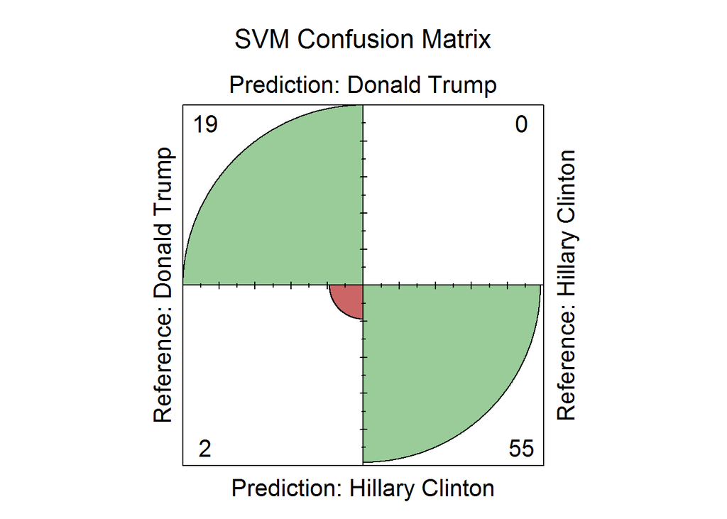

```r
fourfoldplot(cm$table, color = c("#CC6666", "#99CC99"),conf.level = 0, margin = 1, main = "SVM Confusion Matrix")
```

### Random Forest Classifier

The output of the Random Forest Classifier model suggests zero documents are misclassified. The accuracy of the model is 100%. `randomForest` package is used to demonstrate Random Forest Classifier model.

```r
#Get all columns in dataframe
#str(train.c.data, list.len=ncol(train.c.data))

#Adding candidate name to Training data
train.rf.data <- cbind(train.data, speech.data.candidates[speech.train.test == 1])
colnames(train.rf.data)[ncol(train.rf.data)] <- "candidateSpeech"

rfp.fit <- randomForest(candidateSpeech ~ ., data = train.rf.data, method="class")
rfp.prediction= predict(rfp.fit, test.data)

#Generate confusion matrix
cm<-confusionMatrix(rfp.prediction, speech.data.candidates[speech.train.test == 2])
tmp.cm<- as.data.frame(t(cm$byClass))
tmp.cm$Model <- "RFC"
cm.data<- rbind(cm.data,tmp.cm)
cm
```

```
## Confusion Matrix and Statistics
##
##                  Reference
## Prediction        Donald Trump Hillary Clinton
##   Donald Trump              21               0
##   Hillary Clinton            0              55
##
##                Accuracy : 1
##                  95% CI : (0.9526, 1)
##     No Information Rate : 0.7237
##     P-Value [Acc > NIR] : 2.117e-11
##
##                   Kappa : 1
##  Mcnemar's Test P-Value : NA
##
##             Sensitivity : 1.0000
##             Specificity : 1.0000
##          Pos Pred Value : 1.0000
##          Neg Pred Value : 1.0000
##              Prevalence : 0.2763
##          Detection Rate : 0.2763
##    Detection Prevalence : 0.2763
##       Balanced Accuracy : 1.0000
##
##        'Positive' Class : Donald Trump
##
```

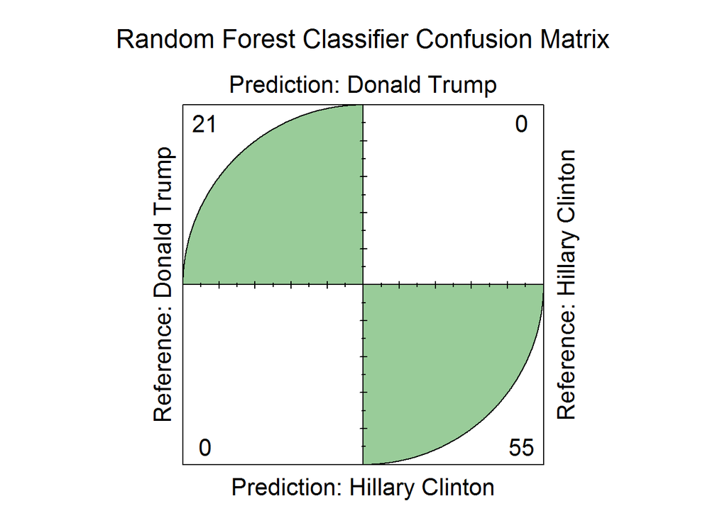

```r
fourfoldplot(cm$table, color = c("#CC6666", "#99CC99"),conf.level = 0, margin = 1, main = "Random Forest Classifier Confusion Matrix")
```

### Maximum Entropy Classifier

The output of the Maximum Entropy Classifier model suggests zero documents are misclassified. The accuracy of the model is 100%. `RTextTools` package is used to demonstrate Random Forest Classifier model.

```r
train.candidates <- factor(speech.data.candidates[speech.train.test == 1])
train.container <- create_container(train.data, train.candidates, trainSize=1:nrow(train.data), virgin=FALSE)

train.model <- train_model(train.container, "MAXENT", kernel="linear", cost=1)
mec.prediction <- predict(train.model, test.data)

cm<-confusionMatrix(mec.prediction[,1], speech.data.candidates[speech.train.test == 2])

tmp.cm<- as.data.frame(t(cm$byClass))
tmp.cm$Model <- "MAXENT"
cm.data<- rbind(cm.data,tmp.cm)
cm
```

```
## Confusion Matrix and Statistics
##
##                  Reference
## Prediction        Donald Trump Hillary Clinton
##   Donald Trump              21               0
##   Hillary Clinton            0              55
##
##                Accuracy : 1
##                  95% CI : (0.9526, 1)
##     No Information Rate : 0.7237
##     P-Value [Acc > NIR] : 2.117e-11
##
##                   Kappa : 1
##  Mcnemar's Test P-Value : NA
##
##             Sensitivity : 1.0000
##             Specificity : 1.0000
##          Pos Pred Value : 1.0000
##          Neg Pred Value : 1.0000
##              Prevalence : 0.2763
##          Detection Rate : 0.2763
##    Detection Prevalence : 0.2763
##       Balanced Accuracy : 1.0000
##
##        'Positive' Class : Donald Trump
##
```

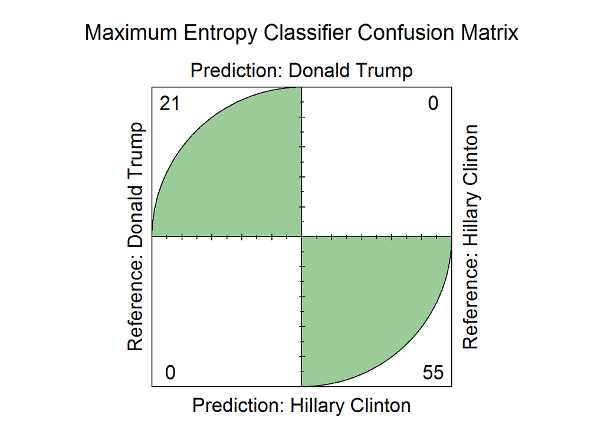

```r
fourfoldplot(cm$table, color = c("#CC6666", "#99CC99"),conf.level = 0, margin = 1, main = "Maximum Entropy Classifier Confusion Matrix")
```

## Unsupervised learning techniques

To demonstrate unsupervised learning techniques, a small dataset consisting of November 2016 speeches of both candidates are used. Unsupervised learning techniques are also known as `Topic Modeling`

### Latent Dirichlet Allocation(LDA)

The number of models to be generated, `k` is calculated using *David Meza’s* work. More information can be found at http://davidmeza1.github.io/2015/07/20/topic-modeling-in-R.html. Output suggests `Topic 7` is best fit for document `1`. `topicmodels` package is used to demonstrate Latent Dirichlet Allocation model.

```r
#str(nov.speech.data.nocandidate, list.len=ncol(nov.speech.data.nocandidate))

#Determine k number of topics - David Meza
#http://davidmeza1.github.io/2015/07/20/topic-modeling-in-R.html
#Instead of Document-Term-Matrix(dtm), dataframe extracted from dtm is used.
#------#
harmonicMean <- function(logLikelihoods, precision = 2000L) {
  llMed <- median(logLikelihoods)
  as.double(llMed - log(mean(exp(-mpfr(logLikelihoods,
                                       prec = precision) + llMed))))
}

seqk <- seq(2, 20, 1)
burnin <- 1000
iter <- 1000
keep <- 50
system.time(fitted_many <- lapply(seqk, function(k) topicmodels::LDA(nov.speech.data.nocandidate, k = k,
                                                     method = "Gibbs",control = list(burnin = burnin,
                                                                         iter = iter, keep = keep) )))
```

```
##    user  system elapsed
##   52.38    0.00   52.56
```

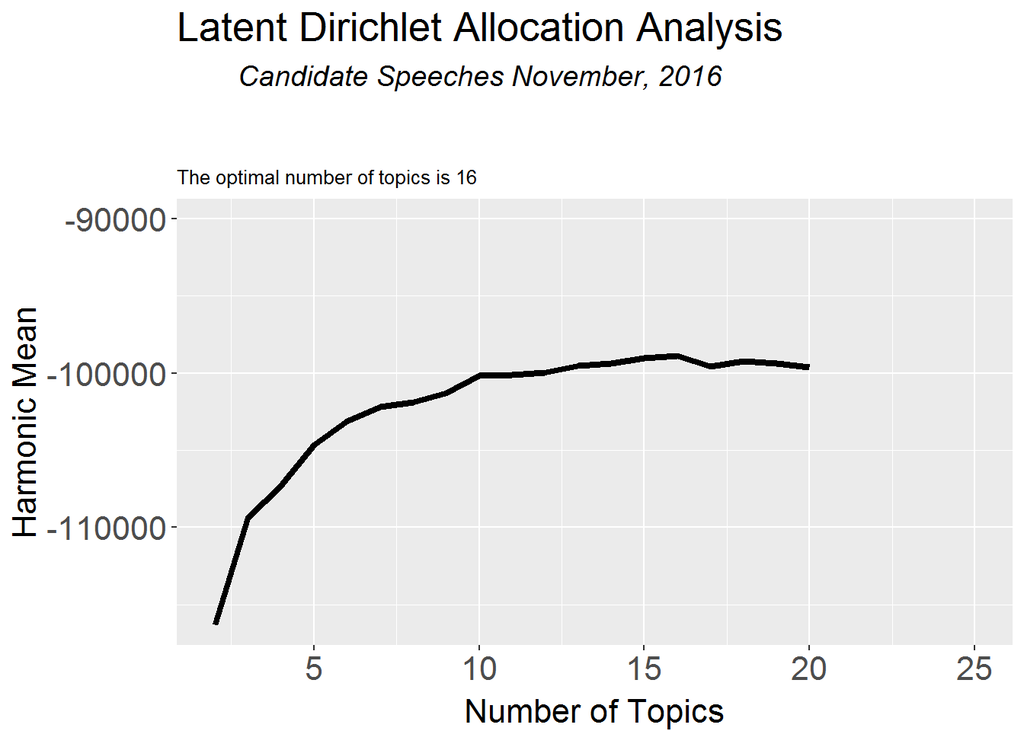

```r
logLiks_many <- lapply(fitted_many, function(L)  L@logLiks[-c(1:(burnin/keep))])

# compute harmonic means
hm_many <- sapply(logLiks_many, function(h) harmonicMean(h))

ot <- paste("The optimal number of topics is", seqk[which.max(hm_many)])

ldaplot <- ggplot(data.frame(seqk, hm_many), aes(x=seqk, y=hm_many)) + geom_path(lwd=1.5) +
  theme(text = element_text(family= NULL),
        axis.title.y=element_text(vjust=1, size=16),
        axis.title.x=element_text(vjust=-.5, size=16),
        axis.text=element_text(size=16),
        plot.title=element_text(size=20)) +
  xlab('Number of Topics') +
  ylab('Harmonic Mean') +
     annotate("text", x = 25, y = -90000, label="") +
  ggtitle(expression(atop("Latent Dirichlet Allocation Analysis", atop(italic("Candidate Speeches November, 2016"), "")))) + labs(subtitle = ot)

ldaplot
```

```r
#------#

#Generate topic models
#Monitor time taken to generate the topics
system.time(nov.speeches.model <- topicmodels::LDA(nov.speech.data.nocandidate, k = seqk[which.max(hm_many)], method = "Gibbs", control = list(iter=1000, seed = 0622)))
```

```
##    user  system elapsed
##    1.75    0.00    1.75
```

```r
nov.speeches.topics <- topicmodels::topics(nov.speeches.model, 1)

#Display top 15 terms.
nov.speeches.terms <- as.data.frame(topicmodels::terms(nov.speeches.model, 15), stringsAsFactors = FALSE)
nov.speeches.terms #[1:8]
```

```
##      Topic 1 Topic 2  Topic 3 Topic 4  Topic 5  Topic 6     Topic 7
## 1   carolina    hard  countri   peopl     know    theyr       bring
## 2   children    serv american    know campaign    debat        care
## 3    everyth everyth   believ    want     work    fight         can
## 4     someon    kind    right     get     best   number        love
## 5  communiti    just   togeth  becaus  hillari     deal    obamacar
## 6       done  across      one    said    peopl      big      health
## 7      black  especi    elect    will     hour     folk        also
## 8   campaign     job    thank   think     made question      believ
## 9     justic    high     hope     got  clinton      end         run
## 10     north  listen   becaus     say    thing    north      replac
## 11    health   never      now   everi      day   believ      school
## 12      take    plan     vote    dont      yet     noth applauseand
## 13       kid     say    still    time     love      use         cut
## 14     insur  actual  everyon    just     much     ever        onli
```

[output cut: 33 more lines]

```r
#Generates dataframe to store the candidate, speech file and the most likely topic
nov.speeches.topics.df <- as.data.frame(nov.speeches.topics)

#Bind Topic Model that best fits the speech
nov.speeches.topics.df <- dplyr::transmute(nov.speeches.topics.df, Id = rownames(nov.speeches.topics.df), Topic = nov.speeches.topics)

nov.speeches.topics.df$Id <- as.integer(nov.speeches.topics.df$Id)

#To test accuracy bind candidate name and speech file values to the dataframe
nov.speeches.topics.df$Candidate <- nov.speech.data.candidates[nov.speeches.topics.df$Id]
nov.speeches.topics.df$SpeechFile <- nov.speech.data.fileNames[nov.speeches.topics.df$Id]

#Generate output
nov.speeches.topics.df %>%
  select (Id, Topic, Candidate, SpeechFile) %>%
  kable(digits = 2, col.names = c("DocumentId", "TopicModelId", "Candidate", "SpeechFile"), format='pandoc', caption = "Best Fit Topic Model to Document using Latent Dirichlet Allocation")
```

Best Fit Topic Model to Document using Latent Dirichlet Allocation

| DocumentId | TopicModelId | Candidate | SpeechFile |
| --- | --- | --- | --- |
| 1 | 7 | Donald Trump | D:/CUNY/607/Week10/Project04/DT_Nov/Donald-J-Trump-November-1-2016-70.txt |
| 2 | 16 | Donald Trump | D:/CUNY/607/Week10/Project04/DT_Nov/Donald-J-Trump-November-2-2016-71.txt |
| 3 | 16 | Donald Trump | D:/CUNY/607/Week10/Project04/DT_Nov/Donald-J-Trump-November-2-2016-72.txt |
| 4 | 4 | Donald Trump | D:/CUNY/607/Week10/Project04/DT_Nov/Donald-J-Trump-November-7-2016-73.txt |
| 5 | 12 | Donald Trump | D:/CUNY/607/Week10/Project04/DT_Nov/Donald-J-Trump-November-9-2016-74.txt |
| 6 | 4 | Hillary Clinton | D:/CUNY/607/Week10/Project04/HC_Nov/Hillary-Clinton-November-3-2016-189.txt |
| 7 | 4 | Hillary Clinton | D:/CUNY/607/Week10/Project04/HC_Nov/Hillary-Clinton-November-3-2016-190.txt |
| 8 | 4 | Hillary Clinton | D:/CUNY/607/Week10/Project04/HC_Nov/Hillary-Clinton-November-3-2016-191.txt |
| 9 | 4 | Hillary Clinton | D:/CUNY/607/Week10/Project04/HC_Nov/Hillary-Clinton-November-4-2016-192.txt |
| 10 | 4 | Hillary Clinton | D:/CUNY/607/Week10/Project04/HC_Nov/Hillary-Clinton-November-7-2016-193.txt |
| 11 | 3 | Hillary Clinton | D:/CUNY/607/Week10/Project04/HC_Nov/Hillary-Clinton-November-7-2016-194.txt |
| 12 | 4 | Hillary Clinton | D:/CUNY/607/Week10/Project04/HC_Nov/Hillary-Clinton-November-7-2016-195.txt |
| 13 | 5 | Hillary Clinton | D:/CUNY/607/Week10/Project04/HC_Nov/Hillary-Clinton-November-9-2016-196.txt |

### Correlated Topic Model(CTM)

Correlated Topic Model is generated using same `k` value from Latent Dirichlet Allocation. Output suggests `Topic 3` is best fit for document `1`. `topicmodels` package is used to demonstrate Correlated Topic Model model.

```r
system.time(nov.speeches.model.ctm <- topicmodels::CTM(nov.speech.data.nocandidate, k = seqk[which.max(hm_many)], method = "VEM", control = list(seed = 0622, var = list(tol = 10^-4), em = list(tol = 10^-3))))
```

```
##    user  system elapsed
##    9.03    0.01    9.05
```

```r
nov.speeches.topics.ctm <- topicmodels::topics(nov.speeches.model.ctm, 1)
nov.speeches.terms.ctm <- as.data.frame(topicmodels::terms(nov.speeches.model.ctm, 15), stringsAsFactors = FALSE)
nov.speeches.terms.ctm #[1:8]
```

```
##    Topic 1 Topic 2       Topic 3  Topic 4  Topic 5  Topic 6 Topic 7
## 1    right    will          will     vote   becaus     know  becaus
## 2     want hillari         peopl   believ     want  countri     say
## 3  countri   theyr       countri     want   realli  hillari   think
## 4     dont    know          veri  america     know    peopl    time
## 5    think    just         great    elect      job    thank     get
## 6      say   peopl          much      can    peopl     work    vote
## 7     know  happen           job    peopl      got campaign    just
## 8     make   great          care     know      can     will    weve
## 9    thing     one        health tomorrow     work      day     day
## 10    time   state         bring   becaus      say american   great
## 11     get     now applausethank    right  america      one    want
## 12  becaus     job           can     well     back     want countri
## 13     one     end          even american michigan  clinton    come
## 14     job    want          love     khan      one     love     ill
```

[output cut: 33 more lines]

```r
# Creates a dataframe to store the candidate, speech file and the most likely topic
nov.speeches.topics.ctm.df <- as.data.frame(nov.speeches.topics.ctm)
nov.speeches.topics.ctm.df <- dplyr::transmute(nov.speeches.topics.ctm.df, Id = rownames(nov.speeches.topics.ctm.df), Topic = nov.speeches.topics.ctm)

#Bind candidate name and speechfile
nov.speeches.topics.ctm.df$Id <- as.integer(nov.speeches.topics.ctm.df$Id)
nov.speeches.topics.ctm.df$Candidate <- nov.speech.data.candidates[nov.speeches.topics.ctm.df$Id]
nov.speeches.topics.ctm.df$SpeechFile <- nov.speech.data.fileNames[nov.speeches.topics.ctm.df$Id]

#Generate output
nov.speeches.topics.ctm.df %>%
  select (Id, Topic, Candidate, SpeechFile) %>%
  kable(digits = 2, col.names = c("DocumentId", "TopicModelId", "Candidate", "SpeechFile"), format='pandoc', caption = "Best Fit Topic Model to Document using Correlated Topic Model")
```

Best Fit Topic Model to Document using Correlated Topic Model

| DocumentId | TopicModelId | Candidate | SpeechFile |
| --- | --- | --- | --- |
| 1 | 3 | Donald Trump | D:/CUNY/607/Week10/Project04/DT_Nov/Donald-J-Trump-November-1-2016-70.txt |
| 2 | 2 | Donald Trump | D:/CUNY/607/Week10/Project04/DT_Nov/Donald-J-Trump-November-2-2016-71.txt |
| 3 | 11 | Donald Trump | D:/CUNY/607/Week10/Project04/DT_Nov/Donald-J-Trump-November-2-2016-72.txt |
| 4 | 14 | Donald Trump | D:/CUNY/607/Week10/Project04/DT_Nov/Donald-J-Trump-November-7-2016-73.txt |
| 5 | 15 | Donald Trump | D:/CUNY/607/Week10/Project04/DT_Nov/Donald-J-Trump-November-9-2016-74.txt |
| 6 | 9 | Hillary Clinton | D:/CUNY/607/Week10/Project04/HC_Nov/Hillary-Clinton-November-3-2016-189.txt |
| 7 | 13 | Hillary Clinton | D:/CUNY/607/Week10/Project04/HC_Nov/Hillary-Clinton-November-3-2016-190.txt |
| 8 | 13 | Hillary Clinton | D:/CUNY/607/Week10/Project04/HC_Nov/Hillary-Clinton-November-3-2016-191.txt |
| 9 | 13 | Hillary Clinton | D:/CUNY/607/Week10/Project04/HC_Nov/Hillary-Clinton-November-4-2016-192.txt |
| 10 | 5 | Hillary Clinton | D:/CUNY/607/Week10/Project04/HC_Nov/Hillary-Clinton-November-7-2016-193.txt |
| 11 | 4 | Hillary Clinton | D:/CUNY/607/Week10/Project04/HC_Nov/Hillary-Clinton-November-7-2016-194.txt |
| 12 | 12 | Hillary Clinton | D:/CUNY/607/Week10/Project04/HC_Nov/Hillary-Clinton-November-7-2016-195.txt |
| 13 | 6 | Hillary Clinton | D:/CUNY/607/Week10/Project04/HC_Nov/Hillary-Clinton-November-9-2016-196.txt |

## Conclusion

- Under supervised learning techniques, Random Forest Classifier and Maximum Entropy Classifier models performed better than kNN and SVM models. Following are the results

```r
cm.data %>% kable(digits = 4, format='pandoc', caption = "Supervised Learning Techniques - Model performance")
```

Supervised Learning Techniques - Model performance

| Sensitivity | Specificity | Pos Pred Value | Neg Pred Value | Precision | Recall | F1 | Prevalence | Detection Rate | Detection Prevalence | Balanced Accuracy | Model |
| --- | --- | --- | --- | --- | --- | --- | --- | --- | --- | --- | --- |
| 0.8571 | 1 | 1 | 0.9483 | 1 | 0.8571 | 0.9231 | 0.2763 | 0.2368 | 0.2368 | 0.9286 | KNN |
| 0.9048 | 1 | 1 | 0.9649 | 1 | 0.9048 | 0.9500 | 0.2763 | 0.2500 | 0.2500 | 0.9524 | SVM |
| 1.0000 | 1 | 1 | 1.0000 | 1 | 1.0000 | 1.0000 | 0.2763 | 0.2763 | 0.2763 | 1.0000 | RFC |
| 1.0000 | 1 | 1 | 1.0000 | 1 | 1.0000 | 1.0000 | 0.2763 | 0.2763 | 0.2763 | 1.0000 | MAXENT |

- Under unsupervised learning techniques, LDA and CTM models generated topic models that are different from each other.

##### References:

- Automated Data Collection With R - Simon Munzert, Christian Rubba, Peter Meißner, Dominic Nyhuis
- http://davidmeza1.github.io/2015/07/20/topic-modeling-in-R.html - David Meza.
- https://www.youtube.com/watch?v=j1V2McKbkLo - Timothy DAuria.
- http://data.library.virginia.edu/reading-pdf-files-into-r-for-text-mining - Clay Ford, University of Virginia.
- https://www.youtube.com/watch?v=dJclNIN-TPo - Bharatendra Rai
- http://www.presidency.ucsb.edu/index.php - John T. Woolley, Gerhard Peters and University of California, Santa Barbara
- http://stackoverflow.com/questions/23891140/r-how-to-visualize-confusion-matrix-using-the-caret-package
- http://vikasgupta1812.github.io/topic-modelling/index.html